# Car Sale Price Prediction

# Get to know the dataset and the features

### 6.fuelType:Diesel vs petrol should make a difference since the price of the fuel and the engine type are not the same.

### 7.tax: the additional amount paid to the government(usually included in the total on road price of car)

### 8.mpg: the miles you can travell per gallon.

### 9.engineSize:The Cubic Capacity(CC) of engine

## Importing Libraries!

```python
import pandas as pd
import numpy as np
import matplotlib.pyplot as plt
import seaborn as sns



from warnings import filterwarnings
filterwarnings('ignore')

from sklearn.preprocessing import LabelEncoder

from sklearn.model_selection import train_test_split

from sklearn.linear_model import LinearRegression

from scipy.stats import shapiro

from statsmodels.stats.outliers_influence import variance_inflation_factor

from sklearn.linear_model import Ridge

from sklearn.model_selection import GridSearchCV

from sklearn.tree import DecisionTreeRegressor

from sklearn.ensemble import RandomForestRegressor

from sklearn.model_selection import validation_curve
from xgboost import XGBRegressor
import os
```

Reading Files and displaying dataset

```python
os.chdir('D:/Projects-data Science/Projects/PRJ Car Price Prediction')
df=pd.read_csv('audi.csv')
df
```

|  | model | year | price | transmission | mileage | fuelType | tax | mpg | engineSize |
| --- | --- | --- | --- | --- | --- | --- | --- | --- | --- |
| 0 | A1 | 2017 | 12500 | Manual | 15735 | Petrol | 150 | 55.4 | 1.4 |
| 1 | A6 | 2016 | 16500 | Automatic | 36203 | Diesel | 20 | 64.2 | 2.0 |
| 2 | A1 | 2016 | 11000 | Manual | 29946 | Petrol | 30 | 55.4 | 1.4 |
| 3 | A4 | 2017 | 16800 | Automatic | 25952 | Diesel | 145 | 67.3 | 2.0 |
| 4 | A3 | 2019 | 17300 | Manual | 1998 | Petrol | 145 | 49.6 | 1.0 |
| ... | ... | ... | ... | ... | ... | ... | ... | ... | ... |
| 10663 | A3 | 2020 | 16999 | Manual | 4018 | Petrol | 145 | 49.6 | 1.0 |
| 10664 | A3 | 2020 | 16999 | Manual | 1978 | Petrol | 150 | 49.6 | 1.0 |
| 10665 | A3 | 2020 | 17199 | Manual | 609 | Petrol | 150 | 49.6 | 1.0 |
| 10666 | Q3 | 2017 | 19499 | Automatic | 8646 | Petrol | 150 | 47.9 | 1.4 |
| 10667 | Q3 | 2016 | 15999 | Manual | 11855 | Petrol | 150 | 47.9 | 1.4 |

10668 rows × 9 columns

```python
df.shape
```

```
(10668, 9)
```

# Data Overview (pandas profiling)

```python
import pandas_profiling as pf
display(pf.ProfileReport(df))
```

[output not shown]

1. No null values are present in the data
2. Duplicate values are present
3. Need to convert datatypes for many variable from categorical to numerical.

```python
display (df.dtypes )
```

```
model            object
year              int64
price             int64
transmission     object
mileage           int64
fuelType         object
tax               int64
mpg             float64
engineSize      float64
dtype: object
```

NULL VALUES IMPUTATION

```python
display (df.isna().sum() )
```

```
model           0
year            0
price           0
transmission    0
mileage         0
fuelType        0
tax             0
mpg             0
engineSize      0
dtype: int64
```

```python
df.info()
```

```
<class 'pandas.core.frame.DataFrame'>
RangeIndex: 10668 entries, 0 to 10667
Data columns (total 9 columns):
 #   Column        Non-Null Count  Dtype
---  ------        --------------  -----
 0   model         10668 non-null  object
 1   year          10668 non-null  int64
 2   price         10668 non-null  int64
 3   transmission  10668 non-null  object
 4   mileage       10668 non-null  int64
 5   fuelType      10668 non-null  object
 6   tax           10668 non-null  int64
 7   mpg           10668 non-null  float64
 8   engineSize    10668 non-null  float64
dtypes: float64(2), int64(4), object(3)
memory usage: 750.2+ KB
```

```python
df.describe ()
```

|  | year | price | mileage | tax | mpg | engineSize |
| --- | --- | --- | --- | --- | --- | --- |
| count | 10668.000000 | 10668.000000 | 10668.000000 | 10668.000000 | 10668.000000 | 10668.000000 |
| mean | 2017.100675 | 22896.685039 | 24827.244001 | 126.011436 | 50.770022 | 1.930709 |
| std | 2.167494 | 11714.841888 | 23505.257205 | 67.170294 | 12.949782 | 0.602957 |
| min | 1997.000000 | 1490.000000 | 1.000000 | 0.000000 | 18.900000 | 0.000000 |
| 25% | 2016.000000 | 15130.750000 | 5968.750000 | 125.000000 | 40.900000 | 1.500000 |
| 50% | 2017.000000 | 20200.000000 | 19000.000000 | 145.000000 | 49.600000 | 2.000000 |
| 75% | 2019.000000 | 27990.000000 | 36464.500000 | 145.000000 | 58.900000 | 2.000000 |
| max | 2020.000000 | 145000.000000 | 323000.000000 | 580.000000 | 188.300000 | 6.300000 |

# EXPLORATORY DATA ANALYSIS

```python
df_num=df.select_dtypes(include=np.number)
df_cat=df.select_dtypes(exclude=np.number)
```

EDA on Numerical Data

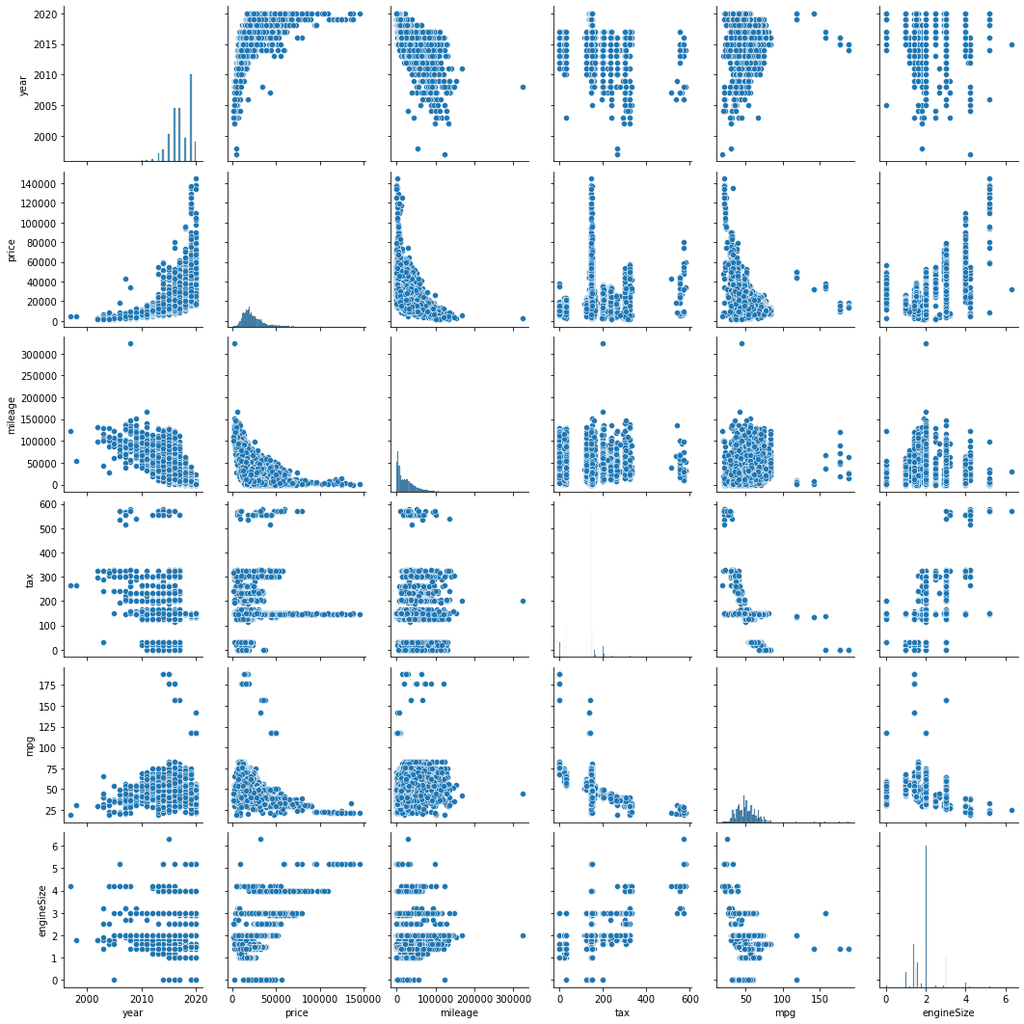

```python
plt.figure(figsize=(15,12))
sns.pairplot(df_num)
plt.show()
```

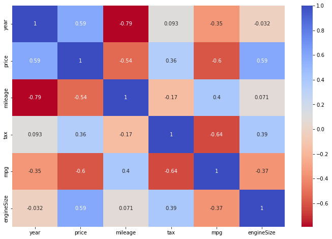

```python
plt.figure(figsize=(12,8))
sns.heatmap(df.corr(),annot=True,cmap=plt.cm.coolwarm_r)
```

[output not shown]

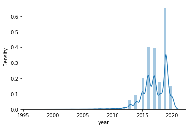

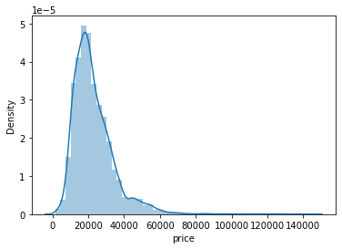

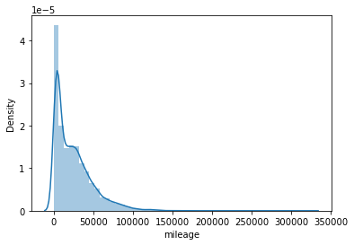

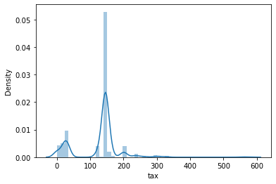

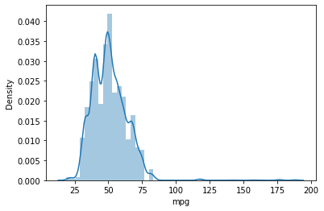

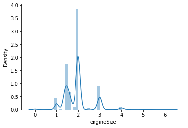

```python
for i in df_num:
    sns.distplot(df_num[i])
    plt.show()
```

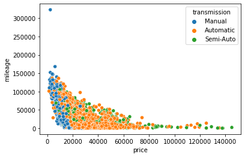

```python
sns.scatterplot(data = df,x = 'price',y = 'mileage',hue='transmission')
plt.show()
```

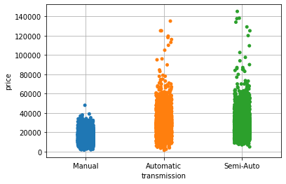

```python
sns.stripplot(y=df['price'],x=df['transmission'])
plt.grid()
plt.show()
```

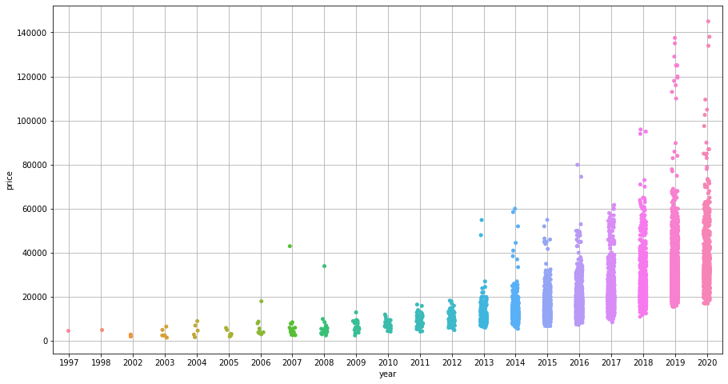

```python
plt.figure(figsize=(15,8))
sns.stripplot(y=df['price'],x=df['year'])
plt.grid()
plt.show()
```

we see that as the price is more for a recently manurfactured car

EDA on Categorical Data

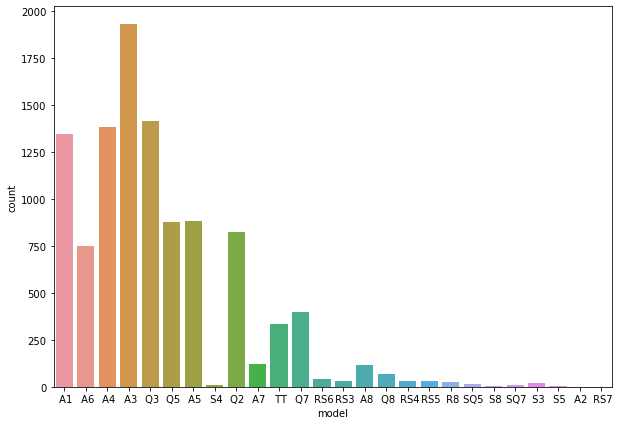

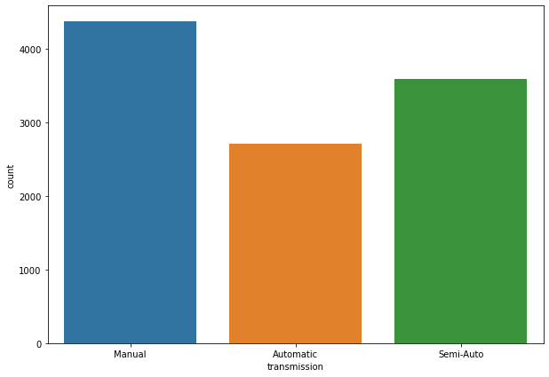

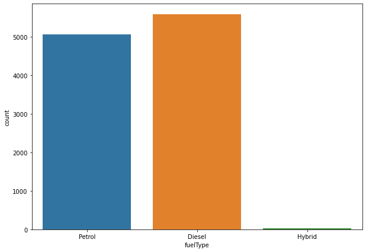

```python
for i in df_cat.iloc[:,:]:
    plt.figure(figsize=(10,7))
    sns.countplot(df[i])
    plt.show()
```

```
Diesel cars are more in our dataset as compared to other fuel types.
Manual cars are more as compared to automatic cars and semi auto
The model A3 has been sold the most
```

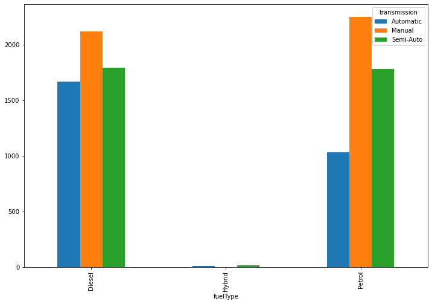

```python
pd.crosstab(df['fuelType'],df['transmission']).plot(kind='bar',figsize=(12,8))
plt.show()
```

Manual transmission is predominant in both Diesel and Petrol cars